# Geeky Projects with R

Edgar Andrés and Mohamed Yassin

22/03/2020

# Introduction

In this notebook we aim to provide knowledge about performing advance Data analytics using R, from the dataset load to further Deep learning approaches passing trough all data transformations required in the process, even this techniques could be used for many tasks, the provided examples will be in the Natural Language Processing (NLP) field, first of all we are going to discuss the modules that we are using in the following sections:

1. RTools: This package is required for building the following packages.
2. tm: This package is used for applying VCorpus structures and the general Natural Language Processing (NLP) pipeline.
3. SnowballC: THis library is used to apply the stemming proccess over words.
4. h2o: This library is use to apply Deep Learning methods over the data.
5. caret: This library is used to apply general Machine Learning methods. (be aware that you might need to install some of the following packages)
- e1071: This library is used to provide support calculations for caret library.
- kernlab: This library is needed for SVM model
6. twitteR: This library is used to access Twitter platform and retrieve data. (be aware that you might need to install some of the following packages)
- devtools: This library is used to provide functions to treat tweets data.
7. quanteda: Quantitative analysis of textual data use R version > 3.5, contains NLP tools and very powerful with data features and very easy to use on CSV, TSv files https://quanteda.io/
- data.table: Fast aggregation of large data and fast in ordered joins, and add/modify/delete of columns. https://cran.r-project.org/web/packages/data.table/index.html
8. tidyverse: A package to read, plot … data using several functions (ggplot2, dplyr, tidyr, readr, purrr, …) use R version > 3.5 https://www.tidyverse.org/
9. lubridate: Fast and userfriendly parsing of date-time data, useful for extraction and updating of components of a date-time value. https://www.rdocumentation.org/packages/lubridate/versions/1.7.4
10. pca3d: This library allows us plotting PCA analysis over data.

```r
install.packages("Rtools") # this package is required for building packages
install.packages("tm") # this package is required for general NLP task
install.packages("SnowballC") # this package is required for stemming functions
install.packages("h2o") # this package is required for deep learning
install.packages("caret") # this package is required for supervised classification
install.packages("e1071") # this package is internally required for caret library
install.packages("kernlab") # this package is internally required for caret library
install.packages("twitteR") # this package is required for twitter API functions
install.packages("tidyverse") # using for show and format data
install.packages("quanteda") # library similar to 'tm' dor NLP pipes
install.packages("lubridate") # library used for plotting purposes
install.packages("data.table") # data frame structure for Quanteda
install.packages("devtools") # this package is required for some twitter functions
install.packages("wordcloud") # this package is required for some unsupervised tricks
install.packages("pca3d")# This library is used for PCA analysis
```

# Fetch datasets with R

## Experiment A (News datasets)

In the current experiment we are working with News dataset that can be downloaded in the following link: http://qwone.com/~jason/20Newsgroups/ , first of all we set the path to the dataset folder and load the data for the next steps with ‘setwd’, then we are going to select and fetch every folder we desire (in this case electronics and religion news), and finally we are going to merge data into a unique data Frame.

```r
library(tm)
setwd("C:/Users/edgar/Desktop/Rprojects/data/20news-bydate/20news-bydate-train")
```

```
The working directory was changed to C:/Users/edgar/Desktop/Rprojects/data/20news-bydate/20news-bydate-train inside a notebook chunk. The working directory will be reset when the chunk is finished running. Use the knitr root.dir option in the setup chunk to change the working directory for notebook …
```

```r
sci.elec = VCorpus(DirSource("sci.electronics"),readerControl=list(language="en"))
talk.religion = VCorpus(DirSource("talk.religion.misc"),readerControl = list(language="en"))
sci.rel=c(sci.elec,talk.religion)
sci.rel[1]
```

```
<<VCorpus>>
Metadata:  corpus specific: 0, document level (indexed): 0
Content:  documents: 1
```

As we can see in this case, the ‘VCorpus’ function generates some custom data Structure that we are going to use in further stages. The library used for getting that data structure is ‘tm’, the same one used on preprocessing the data.

## Experiment B (Twitter)

In the current experiment we aim to retrieve tweets from Twitter and use them for researching purposes, first of all we need to download the Tweets we are going to use on our research, in this case we focus on #mamba Tweets, but ‘serachTwitteR’ function support also esarching by user or tweet type check https://www.rdocumentation.org/packages/twitteR/versions/1.1.9/topics/searchTwitter for further information.

```r
library(twitteR)
library(devtools)

consumer_key <- "of8Nnh1d0kv0ZLBAdYRruPg8z"
consumer_secret <- "BtovPLnpSKQr1QbwoPaGXZjmVshgErtPBgSnBqMMJ1lpxRatEc"
access_key <- "1085774868-x2gHiBwae2Os83nyAwlt4cKygawoY2xXsAct8nm"
access_secret <- "NelDuAZdKfKh9LvveIB2Ll4HTPiK9XkfWrURyrRWPmJSu"
setup_twitter_oauth(consumer_key, consumer_secret, access_key, access_secret)
```

```
[1] "Using direct authentication"
```

```r
mambaTweets = searchTwitteR(searchString = "#mamba", n=100) # retriving 100 tweets of the hash tag (#mamba)
mambaTweetsDataFrames <- do.call("rbind", lapply(mambaTweets, as.data.frame))
mambaTweetsDataFrames[1]
```

| text |
| --- |
| #mamba @kobebryant #forevermamba https://t.co/CgyM1gxG64 |
| after 2 months of being tied up with tattooing finally got it done.\n\nusing prismacolor and caran_dache\nstratmore to… https://t.co/lgYHB3naru |
| Merch, Messages, and More #SubscribetoMyVibe https://t.co/ahxqqLVlX9 #LinkinBio\n\n#Mamba inspired merch avail at… https://t.co/5oTt1V55Df |
| RT @THEREALKIASHINE: Merch, Messages, and More #SubscribetoMyVibe https://t.co/3ZiYgxjM7l #LinkinBio\n\n#Mamba inspired merch avail at @cof… |
| #Mamba https://t.co/S4vTpXXM5T |
| I like ya already #mamba https://t.co/yLe3Preicm |
| RT @THEREALKIASHINE: Merch, Messages, and More #SubscribetoMyVibe https://t.co/3ZiYgxjM7l #LinkinBio\n\n#Mamba inspired merch avail at @cof… |
| Merch, Messages, and More #SubscribetoMyVibe https://t.co/3ZiYgxjM7l #LinkinBio\n\n#Mamba inspired merch avail at… https://t.co/5GYMkT6zxN |
| #Mamba https://t.co/kRTkJZ1Gai |
| RT @3pointpod: Recording a fresh #podcast tomorrow. If you could only rewatch 3 games during quarantine what would they be? #BadBoys? ‘84 #… |

[output cut: 90 more lines]

As we can see in this case we fetched Tweets using the authentication we provide check https://developer.twitter.com/en/docs/basics/authentication/overview for your own Oauth, and retrieve tweets related with #mamba. Notice that in this case as the corpora wasn’t reviwed by any human expert the data quality may be low, and we haven’t access to any related tag, only the raw text.

## Experiment C (Movie Reviews)

```r
library(h2o)# set the h2o connection to the computing unit

h2o.init(ip='localhost', port=54321, nthreads=-1, max_mem_size = '4g') # initialize computing unit
```

[output not shown]

```r
install.packages("data.table")
install.packages("pca3d")
```

```
Error in install.packages : Updating loaded packages
```

```r
imdb.hex = h2o.importFile(path="C:/Users/edgar/Desktop/Rprojects/data/IMDB.csv") # load data
install.packages("pca3d")
# generate training data
imdb.split=h2o.splitFrame(data=imdb.hex, ratios=0.66)
dim(imdb.hex) # show general data
```

```
[1] 2000 1166
```

```r
imdb.train=imdb.split[[1]]
imdb.test=imdb.split[[2]]
dim(imdb.train) # show train
```

[output not shown]

```r
dim(imdb.test) # show test
```

[output not shown]

As we can see in those code chunks we only fetched the local data and divide it into train and test sets, regarding the dimensions we can understand that the original data had 2000 instances with 1166 features each, those features will be used for prediction, and are usually calculated using Language models, in the Experiment D we are covering this issue.

## Experiment D (Amazon Review)

In this case we are going to use the ‘Amazon Review’ task to generate a Language Model (LM), this approach will let us generate certain dense vector to define each learned word numerically, the process will be needed to format the input on many tasks, you can check the next link to understand better the importance https://towardsdatascience.com/what-the-heck-is-word-embedding-b30f67f01c81. In this case we are directly importing a (.CSV) file from certain web direction using ‘h2o’ library.

```r
library(h2o)

h2o.init(ip='localhost', port=54321, nthreads=-1, max_mem_size = '4g') # initialize computing unit
```

[output not shown]

```r
# Load the dataset from the web# Composed of 10,000 reviews, 10 variables each.
# Text is in the last column. Score of the review, 4th
reviews = h2o.importFile("https://s3-us-west-2.amazonaws.com/h2o-tutorials/data/topics/nlp/amazon_reviews/AmazonReviews.csv")
dim(reviews)
```

```
[1] 100000     10
```

```r
colnames(reviews)
```

```
 [1] "ProductId"              "UserId"                 "Summary"                "Score"                  "HelpfulnessDenominator" "Id"
 [7] "ProfileName"            "HelpfulnessNumerator"   "Time"                   "Text"
```

```r
h2o.table(reviews$Score)
```

|  | Score | Count |
| --- | --- | --- |
| 1 | 1 | 9204 |
| 2 | 2 | 5180 |
| 3 | 3 | 7407 |
| 4 | 4 | 14221 |
| 5 | 5 | 63988 |

```
[5 rows x 2 columns]
```

```r
# Create and append a new target column, considering as positive reviews all greater or equal than 4
reviews$PositiveReview <- h2o.ifelse(reviews$Score >= 4, "1", "0")
h2o.table(reviews$PositiveReview)
```

|  | PositiveReview | Count |
| --- | --- | --- |
| 1 | 0 | 21791 |
| 2 | 1 | 78209 |

```
[2 rows x 2 columns]
```

## Experiment E (Amazon Alexa)

In this case we propose another possiblity to fetch local data to automatically generate a data frame from (.TSV) files.

```r
library(data.table)
library(tidyverse)
```

```r
#load the dataset file
#setwd("/home/medysn/Desktop/LAP8")
setwd("C:/Users/edgar/Desktop/Rprojects/data")
```

```
The working directory was changed to C:/Users/edgar/Desktop/Rprojects/data inside a notebook chunk. The working directory will be reset when the chunk is finished running. Use the knitr root.dir option in the setup chunk to change the working directory for notebook chunks.
```

```r
data<-as.data.frame(fread("amazon_alexa.tsv"))

# display the dimensions of your dataset:
dim(data)
```

```
[1] 3150    5
```

```r
View(data)
glimpse(data) #a way to print the columns and the values
```

```
Observations: 3,150
Variables: 5
$ rating           <int> 5, 5, 4, 5, 5, 5, 3, 5, 5, 5, 5, 5, 5, 5, 5,...
$ date             <chr> "31-Jul-18", "31-Jul-18", "31-Jul-18", "31-J...
$ variation        <chr> "Charcoal Fabric", "Charcoal Fabric", "Walnu...
$ verified_reviews <chr> "Love my Echo!", "Loved it!", "Sometimes whi...
$ feedback         <int> 1, 1, 1, 1, 1, 1, 1, 1, 1, 1, 1, 1, 1, 1, 1,...
```

# Preprocessing with R

In this section we are going to learn how to apply the required preprocessing steps for texts, this is called NLP, and in this case we are going to use the libraries ‘tm’ and ‘SnowballC’ for Vcorpus and raw lists structures (Experiments A and B), and some features of the library ‘h2o’ for the previous data Frames.

## Experiment A

In this case we are going to apply ‘tm’ preprocess pipeline to remove the numbers, remove punctuation, transform to lowercase, remove stop words (most frequent and irrelevant as determiners), quit the formatting, stem the words (keep only words root) and finally generate a document tern matrix with every preprocessed terns.

```r
library(tm)
sci.rel
```

```
<<VCorpus>>
Metadata:  corpus specific: 0, document level (indexed): 0
Content:  documents: 968
```

```r
sci.rel.trans=tm_map(sci.rel,removeNumbers)
sci.rel.trans=tm_map(sci.rel.trans,removePunctuation)
sci.rel.trans=tm_map(sci.rel.trans, content_transformer(tolower)) # convert to lowercase
sci.rel.trans=tm_map(sci.rel.trans,removeWords,stopwords("english"))
sci.rel.trans=tm_map(sci.rel.trans,stripWhitespace)

library(SnowballC) # to access Porter's word stemming algorithm
sci.rel.trans=tm_map(sci.rel.trans,stemDocument)
sci.rel.trans
```

```
<<VCorpus>>
Metadata:  corpus specific: 0, document level (indexed): 0
Content:  documents: 968
```

```r
sci.rel.dtm=DocumentTermMatrix(sci.rel.trans)
sci.rel.dtm
```

```
<<DocumentTermMatrix (documents: 968, terms: 13565)>>
Non-/sparse entries: 91543/13039377
Sparsity           : 99%
Maximal term length: 134
Weighting          : term frequency (tf)
```

```r
sci.rel.dtm.90=removeSparseTerms(sci.rel.dtm,sparse=0.9)
sci.rel.dtm.90
```

```
<<DocumentTermMatrix (documents: 968, terms: 118)>>
Non-/sparse entries: 22176/92048
Sparsity           : 81%
Maximal term length: 15
Weighting          : term frequency (tf)
```

```r
type=c(rep("science",591),rep("religion",377)) # create the type vector
sci.rel.dtm.90=cbind(sci.rel.dtm.90,type) # append
sci.rel.dtm.90.ML.matrix=as.data.frame(as.matrix(sci.rel.dtm.90))
sci.rel.dtm.90.ML.matrix
```

|  | actual | also | anoth | anyon | anyth | articl | back | believ | better | build | call | can | case | christian | circuit | come | comput | consid | current | david | day | differ | distribut | doesnt | dont | email | etc | even | fact | … |
| --- | --- | --- | --- | --- | --- | --- | --- | --- | --- | --- | --- | --- | --- | --- | --- | --- | --- | --- | --- | --- | --- | --- | --- | --- | --- | --- | --- | --- | --- | --- |
| 52434 |  |  |  |  |  | 1 |  | 1 |  |  |  |  |  |  |  | 1 |  |  |  |  |  |  |  |  |  |  |  | 1 |  | … |
| 52446 |  |  |  |  |  |  |  | 1 |  |  |  | 1 |  |  |  |  | 1 |  |  |  |  |  | 1 |  |  |  |  | 1 |  | … |
| 52464 |  | 1 |  |  | 1 | 2 | 1 |  | 1 |  | 1 |  |  |  | 4 | 1 | 1 |  |  | 2 |  |  | 1 |  |  |  | 1 |  |  | … |
| 52717 |  |  |  |  |  |  |  |  |  |  |  |  |  |  |  |  | 1 |  |  |  |  |  | 1 |  | 2 |  |  |  |  | … |
| 52718 |  |  |  |  |  |  |  |  |  |  |  | 1 |  |  |  |  |  |  |  |  |  |  |  |  |  | 1 |  |  |  | … |
| 52719 | 3 |  | 1 |  |  | 1 |  |  |  |  |  |  |  |  |  |  |  |  | 2 |  |  |  |  |  |  |  |  |  |  | … |
| 52721 |  |  |  | 1 |  |  |  |  |  |  |  |  |  |  |  |  |  |  |  |  |  |  |  |  |  |  | 1 |  |  | … |
| 52722 |  | 3 |  | 1 |  | 1 |  |  |  |  | 1 | 1 |  |  |  |  |  |  |  |  |  |  |  |  |  |  |  |  |  | … |
| 52723 |  |  |  | 1 |  |  |  |  |  |  | 1 |  |  |  | 1 |  |  |  |  |  |  |  |  |  |  | 1 |  |  |  | … |
| 52724 |  |  | 1 | 2 |  |  |  |  |  |  |  | 1 |  |  | 1 |  |  |  |  |  |  |  | 1 | 1 |  |  |  |  |  | … |

[output cut: 958 more lines]

```r
colnames(sci.rel.dtm.90.ML.matrix)[119]="type"
```

As we can see in the previous chunk, the resultant document tern matrix should be reduce for removing the sparse terns, this helps on overall improving the data quality. Finally we generate a matrix structure disposed for supervised machine learning purposes. That matrix reflects the LM of each sentence as hot vectors (only determining word counts). Finally we assign the last column as types (where we added the categories ‘science’ or ‘religion’).

## Experiment B

In this case we are going to apply the same pipeline as in experiment A, but first we have to normalize the data format into VCorpus as we did in the loading process of the previous experiment.

```r
library(tm) # to use the vectoresource function on R 3.6.2

mambaDocuments = VectorSource(mambaTweetsDataFrames$text) # each doc is a vector
mambaCorpus = VCorpus(mambaDocuments) #our Vcorpus matrix

mambaDocuments_vec = c(mambaCorpus)
mambaDocuments_vec
```

```
<<VCorpus>>
Metadata:  corpus specific: 0, document level (indexed): 0
Content:  documents: 100
```

```r
mambaDocuments.trans=tm_map(mambaDocuments_vec,removeNumbers)
mambaDocuments.trans=tm_map(mambaDocuments.trans,removePunctuation)
mambaDocuments.trans=tm_map(mambaDocuments.trans, content_transformer(tolower)) # convert to lowercase
mambaDocuments.trans=tm_map(mambaDocuments.trans,removeWords,stopwords("english"))
mambaDocuments.trans=tm_map(mambaDocuments.trans,stripWhitespace)

library(SnowballC) # to access Porter's word stemming algorithm
mambaDocuments.trans=tm_map(mambaDocuments.trans,stemDocument)
mambaDocuments.trans
```

```
<<VCorpus>>
Metadata:  corpus specific: 0, document level (indexed): 0
Content:  documents: 100
```

```r
mambaDocuments.dtm=DocumentTermMatrix(mambaDocuments.trans)
mambaDocuments.dtm
```

```
<<DocumentTermMatrix (documents: 100, terms: 527)>>
Non-/sparse entries: 1061/51639
Sparsity           : 98%
Maximal term length: 61
Weighting          : term frequency (tf)
```

```r
mambaDocuments.dtm.90=removeSparseTerms(mambaDocuments.dtm,sparse=0.9)
mambaDocuments.dtm.90
```

```
<<DocumentTermMatrix (documents: 100, terms: 10)>>
Non-/sparse entries: 199/801
Sparsity           : 80%
Maximal term length: 15
Weighting          : term frequency (tf)
```

Finally we achieve the same data structure ‘Document Tern Matrix’ with removed sparse terns. Notice that this proccess could be applied to any kind of retrieved text, and the only thing we should take care of is the input format to the process.

## Experiment D

In this case we are going to preprocess the Amazon reviews datasets, in a similar mode to previous movies reviws, instead of Bag of Words, here we are applying word2vec https://medium.com/@gruizdevilla/introducci%C3%B3n-a-word2vec-skip-gram-model-4800f72c871f to generate the word embeddings, first of all we need to tokenize every clean word.

```r
# Tokenize words
# Set stop words
STOP_WORDS <- read.csv("https://s3-us-west-2.amazonaws.com/h2o-tutorials/data/topics/nlp/amazon_reviews/stopwords.csv", stringsAsFactors = FALSE)$STOP_WORD
# Create a tokenize function that tokenizes the sentences and filters certain words
tokenize <- function(sentences, stop_word = STOP_WORDS){
  # Tokenize sentences by word
  tokenized <- h2o.tokenize(sentences, "\\\\W+")
  # Convert words to lowercase
  tokenized_lower <- h2o.tolower(tokenized)
  # Remove words with one letter
  tokenized_filter <- tokenized_lower[(h2o.nchar(tokenized_lower) >= 2) | is.na(tokenized_lower), ]
  # Remove words with any numbers
  tokenized_words <- tokenized_filter[h2o.grep(pattern = "[0-9]", x = tokenized_filter,invert = TRUE, output.logical = TRUE), ]
  # Remove stop words
  tokenized_words <- tokenized_words[is.na(tokenized_words) | !(tokenized_words %in% STOP_WORDS), ]
  return(tokenized_words)
}
# Run the previous tokenization function from the reviews' text
words <- tokenize(reviews$Text)
head(words)
```

|  | C1 |
| --- | --- |
| 1 | made |
| 2 | china |
| 3 | buy |
| 4 | pet |
| 5 | food |
| 6 | china |

Once we have cleaned all the data, we generate our LM based on word2vec, those models have a powerfull analogy ability, as we can see the retrieval of synonyms is allowed due the nearest words are retrieved on the word embedding space, with the trained lettle model we transform the given data.

```r
# Train a Word2Vec model of 10 dimensions
# It is a computationally demanding process with respect to the vector size
w2v_model <- h2o.word2vec(training_frame = words, vec_size = 40)
# Play with the learned embedding
h2o.findSynonyms(w2v_model, "coffee", count = 5)
```

|  | synonym | score |
| --- | --- | --- |
| 1 | coffe | 0.9268149 |
| 2 | espresso | 0.8917964 |
| 3 | expresso | 0.8894858 |
| 4 | cup | 0.8776686 |
| 5 | brewed | 0.8488385 |

```r
# Trasform original words to vectors by means of the learnt Word2Vec model
review_vecs <- h2o.transform(w2v_model, words, aggregate_method = "AVERAGE")
head(review_vecs)
```

|  | C1 | C2 | C3 | C4 | C5 | C6 | C7 | C8 | C9 | C10 | C11 | C12 | C13 | C14 | C15 | C16 | C17 | C18 | C19 | C20 | C21 | C22 | C23 | C24 | C25 | C26 | C27 | C28 | C29 | … |
| --- | --- | --- | --- | --- | --- | --- | --- | --- | --- | --- | --- | --- | --- | --- | --- | --- | --- | --- | --- | --- | --- | --- | --- | --- | --- | --- | --- | --- | --- | --- |
| 1 | -0.1422317 | -0.17797035 | -0.04219348 | 0.08363083 | 0.01300942 | -0.30298343 | -0.24412796 | 0.11360012 | -0.1283563 | -0.01970244 | 0.19661014 | 0.009127887 | 0.1033304259 | 0.03163133 | 0.2014936 | -0.01758616 | -0.02776145 | 0.08789863 | -0.16416229 | 0.10753837 | 0.2287697 | -0.04890951 | 0.08242720 | 0.07692479 | -0.22905891 | -0.1316161 | 0.23119873 | 0.040904563 | 0.185076535 | … |
| 2 | -0.2930955 | 0.07773062 | 0.12622674 | 0.16669761 | -0.24780910 | -0.21178894 | -0.15874819 | -0.19120459 | -0.1005278 | -0.10577369 | -0.06471241 | -0.038658328 | -0.0005810938 | -0.02805624 | 0.1877453 | 0.03493614 | -0.12080704 | 0.09463308 | -0.19407637 | 0.35319343 | 0.1387516 | -0.15620764 | 0.05536330 | 0.06303977 | -0.08272942 | -0.1624469 | -0.03914963 | -0.068578713 | 0.104314722 | … |
| 3 | -0.2580995 | 0.07375514 | -0.18498392 | 0.11520592 | 0.11622114 | -0.23181297 | -0.15634471 | 0.05053158 | -0.3419909 | -0.03250879 | 0.06453931 | 0.021475330 | 0.0247050840 | -0.10166614 | 0.2333867 | 0.03149230 | -0.01854990 | 0.24531703 | -0.13554420 | 0.22399311 | 0.1473023 | -0.14404258 | 0.12369508 | 0.16895777 | -0.25032586 | -0.1193461 | 0.05173158 | 0.066926554 | 0.111838572 | … |
| 4 | -0.1929839 | 0.05570507 | -0.15569927 | -0.05866889 | -0.01566974 | -0.36265597 | -0.10152203 | 0.03137173 | -0.1820930 | -0.09422887 | 0.11826092 | -0.048909042 | 0.0298350584 | -0.15584683 | 0.2416718 | -0.15509894 | -0.22234064 | 0.24102545 | -0.08229088 | 0.28880093 | 0.2049476 | -0.02800316 | 0.15624937 | 0.08604786 | -0.07626066 | -0.0588004 | 0.03706806 | -0.009944099 | 0.075503893 | … |
| 5 | -0.2439004 | -0.08418133 | -0.18213181 | 0.05845387 | -0.05250729 | -0.36585128 | -0.30378690 | 0.10568677 | -0.2264060 | 0.01384387 | 0.15814283 | -0.145023733 | -0.0113404579 | -0.14367217 | 0.1448006 | -0.04912491 | -0.12256172 | 0.18011986 | -0.17201923 | 0.07742361 | 0.3014130 | -0.06738110 | 0.08407843 | -0.01024505 | -0.15347095 | -0.1705119 | 0.09944193 | -0.024512047 | 0.007127592 | … |
| 6 | -0.2947950 | 0.13076960 | -0.13706809 | 0.06983905 | -0.28147027 | -0.07920624 | -0.04759061 | -0.14770509 | -0.2158265 | 0.06288468 | -0.06544781 | 0.078999661 | -0.0674963966 | -0.02779879 | 0.2747091 | -0.21819678 | -0.24504924 | 0.16630672 | -0.34996033 | 0.17928341 | 0.1754032 | -0.06693922 | -0.13133059 | 0.05014462 | -0.18044494 | -0.1849801 | -0.16948737 | -0.324037910 | 0.171957001 | … |

AS we can see the head words we displayed previously have been converted into the numerical features word2vec model assigned to them, in this case we are not talking in terns of word counts probabilities, semantic, syntactic and lexical features have been codified inside those dense vectors, that’s the reason of being that expensive to calculate. In normal circustances we should train at least with 100 dimension and over large corpora as could be ‘wikipedia’, other alternative is using pre-trained models that we are not currently covering here.

```r
# Calculate indexes for a train-test partition, using the 50th quantile of Time variable
time_split <- h2o.quantile(reviews$Time, prob = 0.5)
reviews$Train <- h2o.ifelse(reviews$Time < time_split, "Yes", "No")
train <- reviews[reviews$Train == "Yes", ]
test <- reviews[reviews$Train == "No", ]
# Add aggregated word embeddings. Append columns
ext_reviews <- h2o.cbind(reviews, review_vecs)
# Split data into training and testing
ext_train <- ext_reviews[ext_reviews$Train == "Yes", ]
dim(ext_train)
```

```
[1] 49993    52
```

```r
ext_test <- ext_reviews[ext_reviews$Train == "No", ]
dim(ext_test)
```

```
[1] 50007    52
```

Once trained the litle model we are binding all the reviews with their respective word embeddings and splitting the data into train and test sets for further steps. Notice that experiment C is already been preprocessed so we directly going to use the previously made train and test sets.

## Experiment E

for preprocessing we can use several tools from the packages, we can clean our dataset, but correcting the values, types. and also for the NLP part we can apply changes and store the results in new columns. this step will be very important while we are going to generate our corpus from reviews.

```r
library(tm)
library(SnowballC) # to access Porter's word stemming algorithm

##Preprocessing
#####################
# renaming columns for ease
colnames(data) = c("Rating", "Date", "Variation", "Review", "Feedback")
#add a column ID
data$id = c(1:nrow(data))
#format the column Review
data$Review = as.character(data$Review)
#format the column of the date
data$Date = as.Date(data$Date, "%d-%b-%y")
# lemmatize alexa reviews
data$Lemma_Review = textstem::lemmatize_strings(data$Review)

#displaying destibutions on columns
## rating distribution
cbind(table(data$Rating))
```

```
  [,1]
1  161
2   96
3  152
4  455
5 2286
```

```r
# variation distribution
cbind(table(data$Variation))
```

```
                             [,1]
Black                         261
Black  Dot                    516
Black  Plus                   270
Black  Show                   265
Black  Spot                   241
Charcoal Fabric               430
Configuration: Fire TV Stick  350
Heather Gray Fabric           157
Oak Finish                     14
Sandstone Fabric               90
Walnut Finish                   9
White                          91
White  Dot                    184
White  Plus                    78
White  Show                    85
White  Spot                   109
```

```r
# feed back distribution
```

# Data visualization with R (Experiment E)

In this section we provide further insight into data visualization, we can use tidyverse library for plotting purposes and to create a corpus we can use the (tm, quanteda) packages, in our case we used quanteda, it’s simple when it comes to handling the tabulated files, and also to take subsets from the main corpus.

## Showing data distributions

Distribution visualization is a step where you know what kingd of data you are treating, and it can help make decision in next steps. in our case our dataset is kind of inbalance. We can use tools from (tidyverse) to plot the results, and also apply filters and sorting (e,g variations by frequency).

```r
library(tidyverse)
library(quanteda)
library(lubridate)
library(data.table)
```

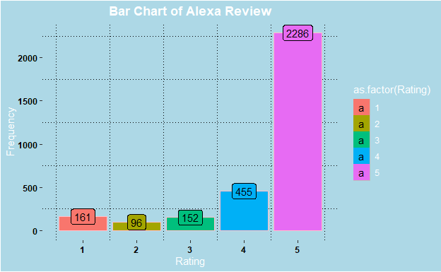

```r
#plot rating distribution
ggplot(data = data, mapping = aes(x = Rating, fill = as.factor(Rating))) +
  geom_bar(color = "pink") +
  labs(title = "Bar Chart of Alexa Review", x = "Rating", y = "Frequency") +
  geom_label(stat = "count",
             position = position_dodge(width = 1),
             hjust = "center",
             aes(label = ..count..))+
  theme(
    # get rid of panel grids
    panel.grid.major = element_blank(),
    panel.grid.minor = element_line(colour = "black",linetype = "dotted"),
    # Change plot and panel background
    plot.background=element_rect(fill = "light blue"),
    panel.background = element_rect(fill = 'light blue'),
    # Change legend
    # legend.position = c(0.6, 0.07),
    # legend.direction = "horizontal",
    legend.background = element_rect(fill = "light blue", color = NA),
    legend.key = element_rect(color = "gray", fill = "light blue"),
    legend.title = element_text(color = "white"),
    legend.text = element_text(color = "white"),
    # align title to top center, top ledt is by default.
    plot.title = element_text(color = "white", hjust = 0.5, face = "bold"),
    # axis ticks to bold black
    axis.text=element_text(colour = "black",face = "bold"),
    axis.title.x = element_text(color = "white"),
    axis.title.y = element_text(color = "white")
  )
```

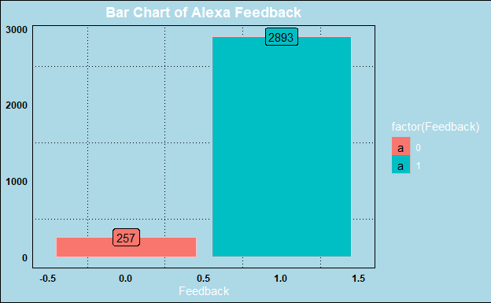

```r
#plot feedback distribution
ggplot(data = data, mapping = aes(x = Feedback, fill = factor(Feedback))) +
  geom_bar(color = "pink") +
  theme_minimal() +
  labs(title = "Bar Chart of Alexa Feedback", x = "Feedback", y = NULL) +
  geom_label(stat = "count",position = position_dodge(width = 1), hjust = "center",
             aes(label = ..count..))+
  theme(
    # get rid of panel grids
    panel.grid.major = element_blank(),
    panel.grid.minor = element_line(colour = "black",linetype = "dotted"),
    # Change plot and panel background
    plot.background=element_rect(fill = "light blue"),
    panel.background = element_rect(fill = 'light blue'),
    # Change legend
    # legend.position = c(0.6, 0.07),
    # legend.direction = "horizontal",
    legend.background = element_rect(fill = "light blue", color = NA),
    legend.key = element_rect(color = "gray", fill = "light blue"),
    legend.title = element_text(color = "white"),
    legend.text = element_text(color = "white"),
    # align title to top center, top ledt is by default.
    plot.title = element_text(color = "white", hjust = 0.5, face = "bold"),
    # axis ticks to bold black
    axis.text=element_text(colour = "black",face = "bold"),
    axis.title.x = element_text(color = "white"),
    axis.title.y = element_text(color = "white")
  )
```

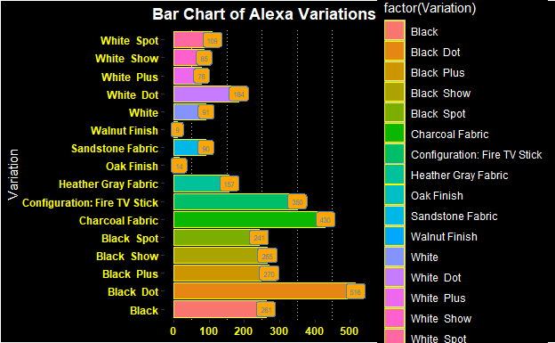

```r
# plot variation distribution
ggplot(data = data, mapping = aes(x = Variation, color = Feedback, fill = factor(Variation))) +
  geom_bar(color = "yellow") +
  labs(title = "Bar Chart of Alexa Variations", x = "Variation", y = NULL) +
  coord_flip()+
  geom_label(stat = "count",position = position_dodge(width = 0.5), hjust = "center", size = 2,
             aes(label = ..count..), color = "steelblue", fill= "orange")+
  theme(
    # get rid of panel grids
    panel.grid.major = element_blank(),
    panel.grid.minor = element_line(colour = "gray",linetype = "dotted"),
    # Change plot and panel background
    plot.background=element_rect(fill = "black"),
    panel.background = element_rect(fill = 'black'),
    # Change legend
    # legend.position = c(0.6, 0.07),
    # legend.direction = "horizontal",
    legend.background = element_rect(fill = "black", color = NA),
    legend.key = element_rect(color = "gray", fill = "black"),
    legend.title = element_text(color = "white"),
    legend.text = element_text(color = "white"),
    # align title to top center, top ledt is by default.
    plot.title = element_text(color = "white", hjust = 0.5, face = "bold"),
    # axis ticks to bold black
    axis.text=element_text(colour = "yellow",face = "bold"),
    axis.title.x = element_text(color = "white"),
    axis.title.y = element_text(color = "white")
  )
```

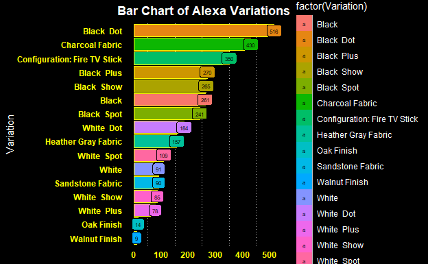

```r
# plot : variation by frequency
alexa_varriation = table(data$Variation) %>% as.data.frame()
colnames(alexa_varriation) = c("Variation", "Count")

ggplot(data = alexa_varriation, mapping = aes(x = reorder(Variation, Count),
                                              y = Count,
                                              fill = factor(Variation))) +
  geom_bar(stat = "identity", color = "yellow") +
  theme_minimal() +
  labs(title = "Bar Chart of Alexa Variations", x = "Variation", y = NULL) +
  coord_flip() +
  geom_label(aes(y = Count, label = Count), size = 2, position = position_dodge(1),
             hjust= "center",vjust = "center")+
  theme(
    # get rid of panel grids
    panel.grid.major = element_blank(),
    panel.grid.minor = element_line(colour = "gray",linetype = "dotted"),
    # Change plot and panel background
    plot.background=element_rect(fill = "black"),
    panel.background = element_rect(fill = 'black'),
    # Change legend
    # legend.position = c(0.6, 0.07),
    # legend.direction = "horizontal",
    legend.background = element_rect(fill = "black", color = NA),
    legend.key = element_rect(color = "gray", fill = "black"),
    legend.title = element_text(color = "white"),
    legend.text = element_text(color = "white"),
    # align title to top center, top ledt is by default.
    plot.title = element_text(color = "white", hjust = 0.5, face = "bold"),
    # axis ticks to bold black
    axis.text=element_text(colour = "yellow",face = "bold"),
    axis.title.x = element_text(color = "white"),
    axis.title.y = element_text(color = "white")
  )
```

## Word analysis with Quanteda

The visualization of data can be done with multiples graphic methods, it’s related to the dataset you are treating and number of dimensions you want to include in the display, in textual datasets, we focus on words, the frequency of appearances, … in the next parts we are going to represent some graphs showing comparisons between positive and negative subsets.

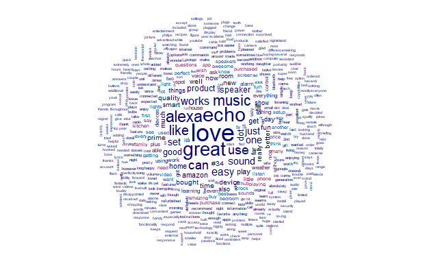

```r
# corpus building
alexa_corpus = corpus(x = data, docid_field = "id",text_field = "Review")
#alexa_corpus = VCorpus(VectorSource(data$Review),readerControl = list(language="en"))

# Positive Reviews ploting with quanteda package
positive_reviews = corpus_subset(alexa_corpus, Feedback == 1)
positive_dfm = positive_reviews %>%
  tokens(remove_punct = TRUE) %>%
  tokens_tolower() %>%
  tokens_remove(stopwords("en")) %>%
  dfm(remove_numbers = TRUE) %>%
  dfm_select(min_nchar = 2)

textplot_wordcloud(positive_dfm)
```

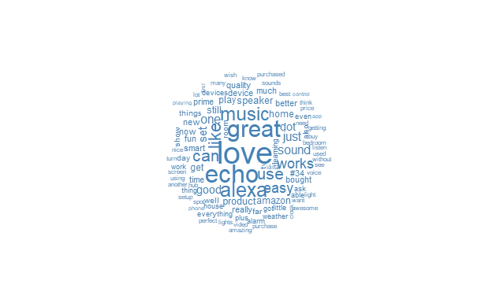

```r
# with 100 words
textplot_wordcloud(positive_dfm, max_words = 100, adjust =  0.1, color = "steelblue")
```

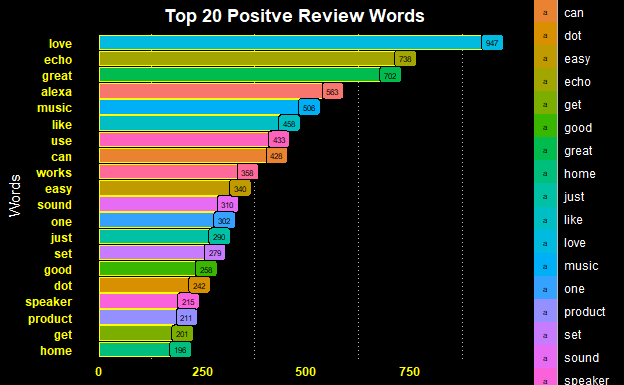

```r
# positive word occurance
positive_words = cbind(colSums(positive_dfm)) %>% as.data.frame()
positive_words$words = rownames(positive_words)
colnames(positive_words) = c("word_count", "word")

ggplot(data = positive_words %>% top_n(n = 20, wt = word_count),
       mapping = aes(x = reorder(word, word_count),
                     y = word_count,
                     fill = word)) +
  geom_bar(stat = "identity", color = "yellow") +
  theme_minimal() +
  labs(title = "Top 20 Positve Review Words", x = "Words", y = NULL) +
  coord_flip() +
  geom_label(aes(y = word_count, label = word_count), size = 2, position = position_dodge(width = 0),
             hjust= "center",vjust = "center")+
  theme(
    # get rid of panel grids
    panel.grid.major = element_blank(),
    panel.grid.minor = element_line(colour = "gray",linetype = "dotted"),
    # Change plot and panel background
    plot.background=element_rect(fill = "black"),
    panel.background = element_rect(fill = 'black'),
    # Change legend
    # legend.position = c(0.6, 0.07),
    # legend.direction = "horizontal",
    legend.background = element_rect(fill = "black", color = NA),
    legend.key = element_rect(color = "gray", fill = "black"),
    legend.title = element_text(color = "white"),
    legend.text = element_text(color = "white"),
    # align title to top center, top ledt is by default.
    plot.title = element_text(color = "white", hjust = 0.5, face = "bold"),
    # axis ticks to bold black
    axis.text=element_text(colour = "yellow",face = "bold"),
    axis.title.x = element_text(color = "white"),
    axis.title.y = element_text(color = "white")
  )
```

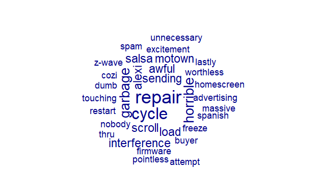

```r
# Negative reviews
negative_review = corpus_subset(alexa_corpus, Feedback == 0)
negative_dfm = negative_review %>%
  tokens(remove_punct = TRUE) %>%
  tokens_tolower() %>%
  tokens_remove(stopwords("en")) %>%
  tokens_select(pattern = featnames(positive_dfm), selection = "remove") %>%
  dfm(remove_numbers = TRUE) %>%
  dfm_select(min_nchar = 2)

textplot_wordcloud(negative_dfm)
```

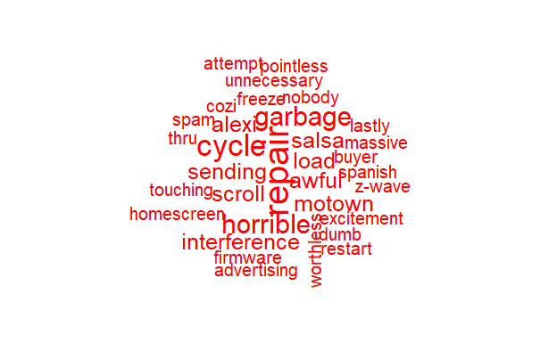

```r
# with 100 words
textplot_wordcloud(negative_dfm, max_words = 100, adjust =  0.1, color = "red")
```

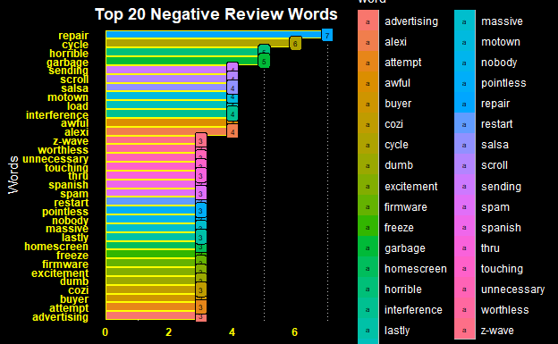

```r
#negative word occurance
negative_words = cbind(colSums(negative_dfm)) %>% as.data.frame()
negative_words$words = rownames(negative_words)
colnames(negative_words) = c("word_count", "word")

ggplot(data = negative_words %>% top_n(n = 20, wt = word_count),
       mapping = aes(x = reorder(word, word_count),
                     y = word_count,
                     fill = word)) +
  geom_bar(stat = "identity", color = "yellow") +
  theme_minimal() +
  labs(title = "Top 20 Negative Review Words", x = "Words", y = NULL) +
  coord_flip() +
  geom_label(aes(y = word_count, label = word_count), size = 2, position = position_dodge(1),
             hjust= "center",vjust = "center")+
  theme(
    # get rid of panel grids
    panel.grid.major = element_blank(),
    panel.grid.minor = element_line(colour = "gray",linetype = "dotted"),
    # Change plot and panel background
    plot.background=element_rect(fill = "black"),
    panel.background = element_rect(fill = 'black'),
    # Change legend
    # legend.position = c(0.6, 0.07),
    # legend.direction = "horizontal",
    legend.background = element_rect(fill = "black", color = NA),
    legend.key = element_rect(color = "gray", fill = "black"),
    legend.title = element_text(color = "white"),
    legend.text = element_text(color = "white"),
    # align title to top center, top ledt is by default.
    plot.title = element_text(color = "white", hjust = 0.5, face = "bold"),
    # axis ticks to bold black
    axis.text=element_text(colour = "yellow",face = "bold"),
    axis.title.x = element_text(color = "white"),
    axis.title.y = element_text(color = "white")
  )
```

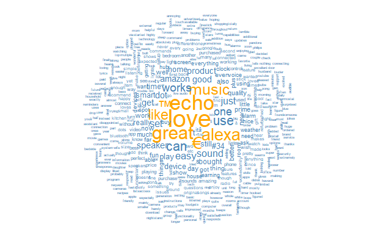

```r
# wordcloud from a document-feature matrix
dfm(alexa_corpus,
    groups = "Feedback",
    tolower = T,
    remove = stopwords("en"),
    remove_punct = T,
    remove_numbers = T) %>%
  textplot_wordcloud(comparison = F,color = c("steelblue","orange"), adjust = 0.1)
```

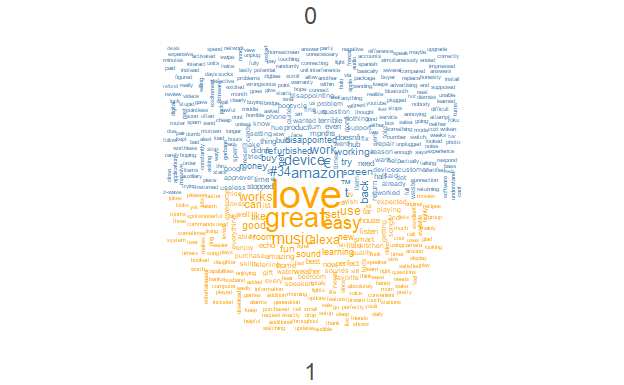

```r
# wordcloud word comparision Positive / negative
dfm(alexa_corpus,
    groups = "Feedback",
    tolower = T,
    remove = stopwords("en"),
    remove_punct = T,
    remove_numbers = T) %>%
  textplot_wordcloud(comparison = T,color = c("steelblue","orange"), adjust = 0.1)
```

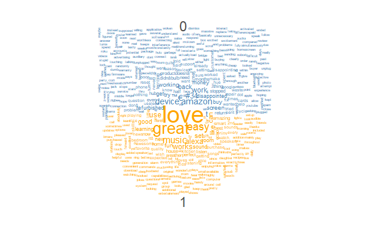

```r
#create a document feature matrix with words from negative and positive
alexa_dfm = alexa_corpus %>%
  tokens(remove_punct = TRUE)%>%
  tokens_tolower() %>%
  tokens_remove(stopwords("en")) %>%
  dfm(groups = "Feedback", remove_numbers = TRUE)
#plot all the features :
textplot_wordcloud(alexa_dfm,
                   comparison = T,
                   labeloffset = 0,
                   color = c("steelblue","orange"),
                   adjust = 0.1)
```

```r
# Top 50 Features
cbind(topfeatures(alexa_dfm,n = 50))
```

```
        [,1]
love     954
echo     830
great    720
€        621
alexa    615
music    538
™        506
like     501
can      466
use      466
works    381
one      345
easy     341
sound    338
just     333
set      297
dot      282
good     273
amazon   254
product  251
get      243
speaker  240
t        227
#34      217
play     215
home     213
device   213
still    204
time     196
really   193
bought   189
smart    182
better   175
now      174
new      174
much     172
prime    170
s        168
also     168
quality  166
well     159
work     154
fun      152
day      152
show     149
far      145
things   144
even     136
got      133
devices  132
```

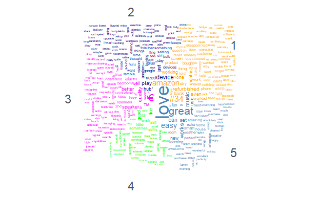

```r
# block the warnings
options(warn=-1)
# Comparing ratings  using wordcloud
alexa_corpus %>%
  tokens(remove_punct = TRUE)%>%
  tokens_tolower() %>%
  tokens_remove(stopwords("en")) %>%
  dfm(groups = "Rating", remove_numbers = TRUE) %>%
  textplot_wordcloud(comparison = T,
                     color = c("orange", "navy","magenta","green", "steelblue"),
                     adjust = 0.0)
```

# Supervised learning with R (Experiment A)

In this section we are going to review two popular machine learning algorithms K nearest neighbours(K-NN) https://towardsdatascience.com/machine-learning-basics-with-the-k-nearest-neighbors-algorithm-6a6e71d01761 and support vector machine (SVM) https://rpubs.com/Joaquin_AR/267926 , all the stages are propossed for previous experiment A stages, first we are reviewing the training / test split and evaluation configuration, then we are training + evaluating K-NN and SVM models, finally we propose confusión and ROC curve tools usage for further understanding the system performance.

## Data split and evaluation configuration

```r
library(caret)
set.seed(107) # a random seed to enable reproducibility
dim(sci.rel.dtm.90.ML.matrix)
```

```
[1] 968 119
```

```r
inTrain <- createDataPartition(y=sci.rel.dtm.90.ML.matrix$type,p=.75,list=FALSE)
training <- sci.rel.dtm.90.ML.matrix[inTrain,]
dim(training)
```

```
[1] 727 119
```

```r
testing <- sci.rel.dtm.90.ML.matrix[-inTrain,]
dim(testing)
```

```
[1] 241 119
```

```r
# fixing the performance estimation procedure
ctrl <- trainControl(method = "repeatedcv",repeats=3)
```

As we can see our training data is composed of 727 examples, and testing data with 241 examples, every instance has 119 features, this means that our vocabulary has 118 words, and in each we determine the appearance word counts, the last column is the type to predict.

## K-NN and SVM training + evaluation

```r
knnModel3x10cv <- train (type ~ ., data=training,method="knn",trControl=ctrl)
svmModel3x10cv <- train (type ~ ., data=training,method="svmLinear",trControl=ctrl)
```

```r
resamps=resamples(list(knn=knnModel3x10cv,svm=svmModel3x10cv))
summary(resamps)
```

```
Call:
summary.resamples(object = resamps)

Models: knn, svm
Number of resamples: 30

Accuracy
         Min.   1st Qu.    Median      Mean   3rd Qu.      Max. NA's
knn 0.5945946 0.6527778 0.6689498 0.6763123 0.6920662 0.7500000    0
svm 0.7671233 0.8194444 0.8414193 0.8391403 0.8625381 0.8918919    0

Kappa
           Min.   1st Qu.    Median      Mean   3rd Qu.      Max. NA's
knn -0.02682701 0.1541353 0.2058824 0.2199043 0.2832900 0.4044118    0
svm  0.52214093 0.6094454 0.6662050 0.6594975 0.7173386 0.7703646    0
```

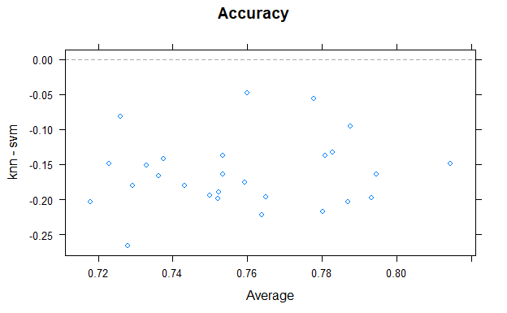

```r
xyplot(resamps,what="BlandAltman")
```

```r
diffs<-diff(resamps)
summary(diffs)
```

```
Call:
summary.diff.resamples(object = diffs)

p-value adjustment: bonferroni
Upper diagonal: estimates of the difference
Lower diagonal: p-value for H0: difference = 0

Accuracy
    knn       svm
knn           -0.1628
svm < 2.2e-16

Kappa
    knn       svm
knn           -0.4396
svm < 2.2e-16
```

## Confusion matrix

In this case we review the detailed Confusion matrix for SVM model, this will help us understanding better the target model performance. That ’a priori seems to be better as we have seen in the previous section.

```r
svmModelClasses <- predict(svmModel3x10cv, newdata = testing, type = "raw")
confusionMatrix(data=svmModelClasses,testing$type)
```

```
Confusion Matrix and Statistics

          Reference
Prediction religion science
  religion       77      19
  science        17     128

               Accuracy : 0.8506
                 95% CI : (0.7992, 0.8931)
    No Information Rate : 0.61
    P-Value [Acc > NIR] : 2.454e-16

                  Kappa : 0.6873

 Mcnemar's Test P-Value : 0.8676

            Sensitivity : 0.8191
            Specificity : 0.8707
         Pos Pred Value : 0.8021
         Neg Pred Value : 0.8828
             Prevalence : 0.3900
         Detection Rate : 0.3195
   Detection Prevalence : 0.3983
      Balanced Accuracy : 0.8449

       'Positive' Class : religion
```

After this short experiment we can ensure that SVM reaches good performance out 0.85 predicting religion and science documents, even the approach used is pretty simple, the tools used showed poerfull strength, this confusion matrix could also be displayed for K NN but we are not interested on precise the Baseline performance in this section.

## ROC curve

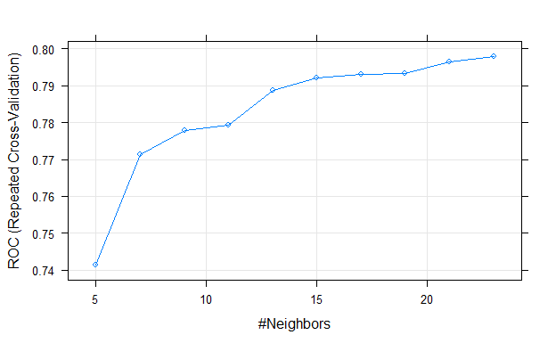

```r
library(pROC)
ctrl <- trainControl(method = "repeatedcv",repeats=3, classProbs=TRUE,
                     summaryFunction=twoClassSummary)

knnModel3x10cvROC <- train (type ~ ., data=training,method="knn",trControl=ctrl,
                            metric="ROC",tuneLength=10)
plot(knnModel3x10cvROC)
```

# Unsupervised learning with R (Experiment B)

In this section we review clustering meethods on R, in this case we are working with tweets as raw texts without labels, so we are going to figurate which are the word distribution over this topic.

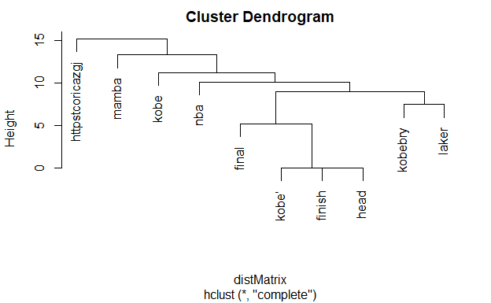

```r
distMatrix=dist(t(scale(as.matrix(mambaDocuments.dtm.90))))
termClustering=hclust(distMatrix, method="complete")
plot(termClustering)
```

As we can deduce from the dendogram, the topic in general terns that those were discussing was related to the Kobe bryan death whose son was mamba. With this example we try to adress the possibilities on tweet analysis with clustering methods. We also provide some visualization features over data to support owr previous hyphothesis, in this case we are going to show a word cloud.

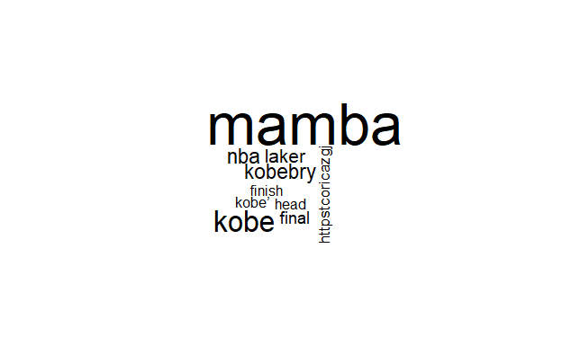

```r
library(wordcloud)
# calculate the frequency of words and sort in descending order.
wordFreqs=sort(colSums(as.matrix(mambaDocuments.dtm.90)),decreasing=TRUE)
wordcloud(words=names(wordFreqs),freq=wordFreqs)
```

And as we can see, the most frequent words are related to Mamba and Kobe, as we mentioned previously those where father and daugther, that god keeps on side (RIP), and as those terns are more frequent we ensure that as we thougth the tweets talk about that topic.

# Deep Learnig with R

In this case we aim to provide some Deep Learning usage examples using H2o library, as we mentioned before we are applying a simple neural network (Multilayer Perceptron) with 3 hidden layers 10 units each.

## Experiment C

Both C and D experiment propose the same deep learning model, and we aim to compare them in performance, Check https://medium.com/inveterate-learner/deep-learning-book-chapter-8-optimization-for-training-deep-models-part-i-20ae75984cb2 to better understand what’s going on inside the model.

### Training deep model (Multilayer perceptron)

In this case we train a deep model to estimate the polarity of movies reviews based on the BAg of words extracted features, this model is the provided ‘baseline’ to test the strength of the previously generated word embeddings.

```r
# fixing the predictors and output variable
# fixing three layers of 100 neurons each
modelDL <- h2o.deeplearning(x=2:1166, y=1, training_frame = imdb.train, hidden = c(10,10,10))
```

```
Dropping bad and constant columns: [of_binarized, the_binarized, and_binarized].
```

```r
predictionsDL=h2o.predict(object=modelDL,newdata=imdb.test)
# the object shows the a-posteriori probabilities of belonging to each class for each test sample
predictionsDL
```

|  | predict | neg | pos |
| --- | --- | --- | --- |
| 1 | neg | 0.9984862 | 1.513834e-03 |
| 2 | neg | 0.9998548 | 1.451725e-04 |
| 3 | neg | 0.9999456 | 5.436065e-05 |
| 4 | neg | 0.9999019 | 9.810012e-05 |
| 5 | neg | 0.3270961 | 6.729039e-01 |
| 6 | neg | 0.9123035 | 8.769654e-02 |

```
[661 rows x 3 columns]
```

### Calculate performance

In this section we disscuss how to evaluate the performance of deep learning models using h2o library, in the provided report we provide evry single usefull metric to understand possible gaps on training as overfitting (MSE, RMSE and Logloss), and we also provide comparison metrics to determine the performance (AUC, Gini, F1 …).

```r
# calculate model performance. The output, first a confusion matrix and then a
# large set of performance statistics: the maximum value of each metric when
# changing the belonging probability threshold to the positive class (0.5, by default)
performanceDL=h2o.performance(modelDL,imdb.test)
performanceDL # performance report
```

```
H2OBinomialMetrics: deeplearning

MSE:  0.1748651
RMSE:  0.4181688
LogLoss:  0.8253312
Mean Per-Class Error:  0.2063542
AUC:  0.8773319
AUCPR:  0.7704322
Gini:  0.7546637

Confusion Matrix (vertical: actual; across: predicted) for F1-optimal threshold:
```

|  | neg | pos | Error | Rate |
| --- | --- | --- | --- | --- |
| neg | 248 | 73 | 0.227414 | =73/321 |
| pos | 63 | 277 | 0.185294 | =63/340 |
| Totals | 311 | 350 | 0.205749 | =136/661 |

```
Maximum Metrics: Maximum metrics at their respective thresholds
```

|  | metric | threshold | value | idx |
| --- | --- | --- | --- | --- |
| 1 | max f1 | 0.290368 | 0.802899 | 208 |
| 2 | max f2 | 0.003107 | 0.883145 | 350 |
| 3 | max f0point5 | 0.948769 | 0.825826 | 108 |
| 4 | max accuracy | 0.818276 | 0.794251 | 153 |
| 5 | max precision | 0.999923 | 0.971154 | 6 |
| 6 | max recall | 0.000003 | 1.000000 | 399 |
| 7 | max specificity | 0.999999 | 0.993769 | 0 |
| 8 | max absolute_mcc | 0.818276 | 0.595564 | 153 |
| 9 | max min_per_class_accuracy | 0.423506 | 0.785047 | 194 |
| 10 | max mean_per_class_accuracy | 0.818276 | 0.796083 | 153 |

[output cut: 8 more lines]

```
Gains/Lift Table: Extract with `h2o.gainsLift(<model>, <data>)` or `h2o.gainsLift(<model>, valid=<T/F>, xval=<T/F>)`
```

```r
# area under the ROC curve: true positives versus false positives
h2o.auc(performanceDL) # roc metric
```

```
[1] 0.8773319
```

## Experiment D

In this case we use the previous features generated with word2vec, but we want to insigth the power of LMs even with low training quality. In this case we train the same Multilayer perceptron as in the previous experiment, then we provide the same performance view to allow comparing both system performance.

### Training deep model (Multilayer perceptron) with word embeddings as input

In this case we need to define the input schema of the Amazon Reviews dataset with the generated review vecs. In this case we also add the confusion matrix to allow better estimation of the strength that LM has to represent the problem.

```r
library(h2o)
# Train a deep learning predictive model
# Fix the predictors: 4 original and transformed vector's 10 dimensions
predictors <- c('ProductId', 'UserId', 'HelpfulnessNumerator', 'HelpfulnessDenominator','Time', colnames(review_vecs))

response <- c('PositiveReview')

# Learn the model: any operation will take time. Be careful with parameters' values
# An idea to limit the computation: reduce the number of training samples with previous time_split
# Be patient: once the model is learnt, future usage for prediction is justified
modelDL <- h2o.deeplearning(x=predictors, y=response, training_frame =  ext_train, hidden = c(10,10,10))
# calculate model performance. The output, first a confusion matrix and then a
# large set of performance statistics: the maximum value of each metric when
# changing the belonging probability threshold to the positive class (0.5, by default)
performanceDL=h2o.performance(modelDL,ext_test)
performanceDL # performance report
```

```
H2OBinomialMetrics: deeplearning

MSE:  0.1179877
RMSE:  0.3434934
LogLoss:  0.3702006
Mean Per-Class Error:  0.2800148
AUC:  0.8787617
AUCPR:  0.946045
Gini:  0.7575234

Confusion Matrix (vertical: actual; across: predicted) for F1-optimal threshold:
```

|  | 0 | 1 | Error | Rate |
| --- | --- | --- | --- | --- |
| 0 | 5775 | 5943 | 0.507168 | =5943/11718 |
| 1 | 2024 | 36265 | 0.052861 | =2024/38289 |
| Totals | 7799 | 42208 | 0.159318 | =7967/50007 |

```
Maximum Metrics: Maximum metrics at their respective thresholds
```

|  | metric | threshold | value | idx |
| --- | --- | --- | --- | --- |
| 1 | max f1 | 0.298181 | 0.901027 | 307 |
| 2 | max f2 | 0.069826 | 0.946777 | 388 |
| 3 | max f0point5 | 0.605263 | 0.898552 | 201 |
| 4 | max accuracy | 0.362709 | 0.842282 | 285 |
| 5 | max precision | 0.994307 | 0.997108 | 4 |
| 6 | max recall | 0.031552 | 1.000000 | 399 |
| 7 | max specificity | 0.998390 | 0.999829 | 0 |
| 8 | max absolute_mcc | 0.503618 | 0.543459 | 238 |
| 9 | max min_per_class_accuracy | 0.667951 | 0.795947 | 179 |
| 10 | max mean_per_class_accuracy | 0.695837 | 0.796862 | 167 |

[output cut: 8 more lines]

```
Gains/Lift Table: Extract with `h2o.gainsLift(<model>, <data>)` or `h2o.gainsLift(<model>, valid=<T/F>, xval=<T/F>)`
```

```r
# area under the ROC curve: true positives versus false positives
h2o.auc(performanceDL) # roc metricç
```

```
[1] 0.8787617
```

```r
# Confusion matrix is computed on the test partition, `ext_test'
h2o.confusionMatrix(modelDL, valid = TRUE)
```

```
No validation metrics available.
```

### Best features Analysis

Here we estimate the performance of each training feature to allow underrstanding which are used for this final result. We display the best 10 and estimate the importance using ‘varimp’.

```r
# Calculate variables' univariate relevance in the model
# I am not sure how it is calculated
h2o.varimp(modelDL)
```

```
Variable Importances:
```

|  | variable | relative_importance | scaled_importance | percentage |
| --- | --- | --- | --- | --- |
| 1 | HelpfulnessNumerator | 1.000000 | 1.000000 | 0.000660 |
| 2 | HelpfulnessDenominator | 0.901457 | 0.901457 | 0.000595 |
| 3 | UserId.ABK32ED0M15MR | 0.283375 | 0.283375 | 0.000187 |
| 4 | ProductId.B001EO5U3I | 0.227001 | 0.227001 | 0.000150 |
| 5 | ProductId.B000FI2VHM | 0.202673 | 0.202673 | 0.000134 |

|  | variable | relative_importance | scaled_importance | percentage |
| --- | --- | --- | --- | --- |
| 103336 | ProductId.B0000TVVB8 | 0.003657 | 0.003657 | 0.000002 |
| 103337 | ProductId.B002WWHY58 | 0.003496 | 0.003496 | 0.000002 |
| 103338 | UserId.A24X7SKKQZYMPV | 0.003488 | 0.003488 | 0.000002 |
| 103339 | UserId.A3SRRCST5CI4IE | 0.003334 | 0.003334 | 0.000002 |
| 103340 | UserId.missing(NA) | 0.000000 | 0.000000 | 0.000000 |
| 103341 | ProductId.missing(NA) | 0.000000 | 0.000000 | 0.000000 |

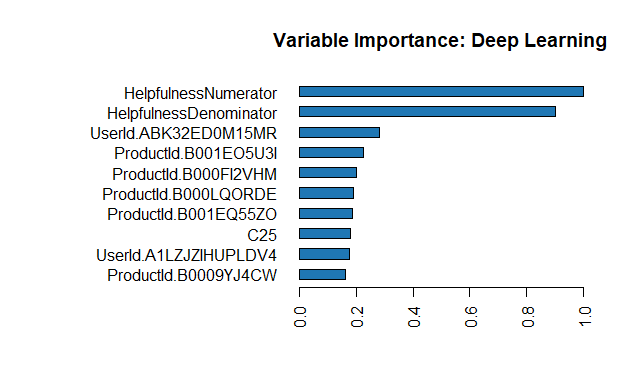

```r
h2o.varimp_plot(modelDL,10)
```

Finally we provide PCA analysis over the variables to understand which are the best dimensions for the current task. For further information check https://cran.r-project.org/web/packages/pca3d/vignettes/pca3d.pdf , in this case we show how to plot PCA for 2 and 3 dimensions, in the case of PCA 3d the output is an interactive window, so must be run to display it. Notice that for the three dimensinal plot we divided scoresfollowing the next mapping (3 = 1), (1,2 = 0) and (4,5 = 2).

```r
library(pca3d)
library(hablar)

head(review_vecs)
```

|  | C1 | C2 | C3 | C4 | C5 | C6 | C7 | C8 | C9 | C10 | C11 | C12 | C13 | C14 | C15 | C16 | C17 | C18 | C19 | C20 | C21 | C22 | C23 | C24 | C25 | C26 | C27 | C28 | C29 | … |
| --- | --- | --- | --- | --- | --- | --- | --- | --- | --- | --- | --- | --- | --- | --- | --- | --- | --- | --- | --- | --- | --- | --- | --- | --- | --- | --- | --- | --- | --- | --- |
| 1 | -0.1422317 | -0.17797035 | -0.04219348 | 0.08363083 | 0.01300942 | -0.30298343 | -0.24412796 | 0.11360012 | -0.1283563 | -0.01970244 | 0.19661014 | 0.009127887 | 0.1033304259 | 0.03163133 | 0.2014936 | -0.01758616 | -0.02776145 | 0.08789863 | -0.16416229 | 0.10753837 | 0.2287697 | -0.04890951 | 0.08242720 | 0.07692479 | -0.22905891 | -0.1316161 | 0.23119873 | 0.040904563 | 0.185076535 | … |
| 2 | -0.2930955 | 0.07773062 | 0.12622674 | 0.16669761 | -0.24780910 | -0.21178894 | -0.15874819 | -0.19120459 | -0.1005278 | -0.10577369 | -0.06471241 | -0.038658328 | -0.0005810938 | -0.02805624 | 0.1877453 | 0.03493614 | -0.12080704 | 0.09463308 | -0.19407637 | 0.35319343 | 0.1387516 | -0.15620764 | 0.05536330 | 0.06303977 | -0.08272942 | -0.1624469 | -0.03914963 | -0.068578713 | 0.104314722 | … |
| 3 | -0.2580995 | 0.07375514 | -0.18498392 | 0.11520592 | 0.11622114 | -0.23181297 | -0.15634471 | 0.05053158 | -0.3419909 | -0.03250879 | 0.06453931 | 0.021475330 | 0.0247050840 | -0.10166614 | 0.2333867 | 0.03149230 | -0.01854990 | 0.24531703 | -0.13554420 | 0.22399311 | 0.1473023 | -0.14404258 | 0.12369508 | 0.16895777 | -0.25032586 | -0.1193461 | 0.05173158 | 0.066926554 | 0.111838572 | … |
| 4 | -0.1929839 | 0.05570507 | -0.15569927 | -0.05866889 | -0.01566974 | -0.36265597 | -0.10152203 | 0.03137173 | -0.1820930 | -0.09422887 | 0.11826092 | -0.048909042 | 0.0298350584 | -0.15584683 | 0.2416718 | -0.15509894 | -0.22234064 | 0.24102545 | -0.08229088 | 0.28880093 | 0.2049476 | -0.02800316 | 0.15624937 | 0.08604786 | -0.07626066 | -0.0588004 | 0.03706806 | -0.009944099 | 0.075503893 | … |
| 5 | -0.2439004 | -0.08418133 | -0.18213181 | 0.05845387 | -0.05250729 | -0.36585128 | -0.30378690 | 0.10568677 | -0.2264060 | 0.01384387 | 0.15814283 | -0.145023733 | -0.0113404579 | -0.14367217 | 0.1448006 | -0.04912491 | -0.12256172 | 0.18011986 | -0.17201923 | 0.07742361 | 0.3014130 | -0.06738110 | 0.08407843 | -0.01024505 | -0.15347095 | -0.1705119 | 0.09944193 | -0.024512047 | 0.007127592 | … |
| 6 | -0.2947950 | 0.13076960 | -0.13706809 | 0.06983905 | -0.28147027 | -0.07920624 | -0.04759061 | -0.14770509 | -0.2158265 | 0.06288468 | -0.06544781 | 0.078999661 | -0.0674963966 | -0.02779879 | 0.2747091 | -0.21819678 | -0.24504924 | 0.16630672 | -0.34996033 | 0.17928341 | 0.1754032 | -0.06693922 | -0.13133059 | 0.05014462 | -0.18044494 | -0.1849801 | -0.16948737 | -0.324037910 | 0.171957001 | … |

```r
data<-as.data.frame(review_vecs)
data %>% rationalize()
```

| C1 | C2 | C3 | C4 | C5 | C6 | C7 | C8 | C9 | C10 | C11 | C12 | C13 | C14 | C15 | C16 | C17 | C18 | C19 | C20 | C21 | C22 | C23 | C24 | C25 | C26 | C27 | C28 | C29 | C30 | … |
| --- | --- | --- | --- | --- | --- | --- | --- | --- | --- | --- | --- | --- | --- | --- | --- | --- | --- | --- | --- | --- | --- | --- | --- | --- | --- | --- | --- | --- | --- | --- |
| -0.1422317028 | -1.779703e-01 | -0.0421934761 | 8.363083e-02 | 0.0130094243 | -3.029834e-01 | -2.441280e-01 | 0.1136001199 | -0.1283563077 | -1.970244e-02 | 1.966101e-01 | 0.0091278870 | 0.1033304259 | 0.0316313282 | 0.201493591 | -1.758616e-02 | -0.0277614500 | 0.087898634 | -0.164162293 | 0.1075383723 | 0.2287697196 | -0.0489095114 | 0.0824271962 | 7.692479e-02 | -0.2290589064 | -0.131616071 | 0.2311987281 | 4.090456e-02 | 0.1850765347 | -2.973555e-01 | … |
| -0.2930954993 | 7.773062e-02 | 0.1262267381 | 1.666976e-01 | -0.2478090972 | -2.117889e-01 | -1.587482e-01 | -0.1912045926 | -0.1005278304 | -1.057737e-01 | -6.471241e-02 | -0.0386583284 | -0.0005810938 | -0.0280562397 | 0.187745288 | 3.493614e-02 | -0.1208070442 | 0.094633080 | -0.194076374 | 0.3531934321 | 0.1387516111 | -0.1562076360 | 0.0553632975 | 6.303977e-02 | -0.0827294216 | -0.162446871 | -0.0391496271 | -6.857871e-02 | 0.1043147221 | -3.146796e-02 | … |
| -0.2580995262 | 7.375514e-02 | -0.1849839240 | 1.152059e-01 | 0.1162211373 | -2.318130e-01 | -1.563447e-01 | 0.0505315848 | -0.3419909179 | -3.250879e-02 | 6.453931e-02 | 0.0214753300 | 0.0247050840 | -0.1016661376 | 0.233386740 | 3.149230e-02 | -0.0185499042 | 0.245317027 | -0.135544196 | 0.2239931077 | 0.1473022699 | -0.1440425813 | 0.1236950755 | 1.689578e-01 | -0.2503258586 | -0.119346149 | 0.0517315827 | 6.692655e-02 | 0.1118385717 | -2.157991e-01 | … |
| -0.1929838955 | 5.570507e-02 | -0.1556992680 | -5.866889e-02 | -0.0156697351 | -3.626560e-01 | -1.015220e-01 | 0.0313717313 | -0.1820929796 | -9.422887e-02 | 1.182609e-01 | -0.0489090420 | 0.0298350584 | -0.1558468342 | 0.241671816 | -1.550989e-01 | -0.2223406434 | 0.241025448 | -0.082290880 | 0.2888009250 | 0.2049475908 | -0.0280031618 | 0.1562493742 | 8.604786e-02 | -0.0762606636 | -0.058800396 | 0.0370680578 | -9.944099e-03 | 0.0755038932 | -2.550465e-02 | … |
| -0.2439004332 | -8.418133e-02 | -0.1821318120 | 5.845387e-02 | -0.0525072888 | -3.658513e-01 | -3.037869e-01 | 0.1056867689 | -0.2264060080 | 1.384387e-02 | 1.581428e-01 | -0.1450237334 | -0.0113404579 | -0.1436721683 | 0.144800618 | -4.912491e-02 | -0.1225617230 | 0.180119857 | -0.172019228 | 0.0774236098 | 0.3014129698 | -0.0673810989 | 0.0840784311 | -1.024505e-02 | -0.1534709483 | -0.170511886 | 0.0994419307 | -2.451205e-02 | 0.0071275923 | -2.616287e-01 | … |
| -0.2947950065 | 1.307696e-01 | -0.1370680928 | 6.983905e-02 | -0.2814702690 | -7.920624e-02 | -4.759061e-02 | -0.1477050930 | -0.2158264667 | 6.288468e-02 | -6.544781e-02 | 0.0789996609 | -0.0674963966 | -0.0277987886 | 0.274709135 | -2.181968e-01 | -0.2450492382 | 0.166306719 | -0.349960327 | 0.1792834103 | 0.1754031628 | -0.0669392198 | -0.1313305944 | 5.014462e-02 | -0.1804449409 | -0.184980139 | -0.1694873720 | -3.240379e-01 | 0.1719570011 | -6.348777e-03 | … |
| -0.1887574941 | -8.955287e-03 | 0.1631096154 | 2.337351e-01 | -0.0331022739 | -3.467637e-01 | -1.464731e-01 | 0.1806332171 | 0.0655766129 | 4.050523e-02 | 1.109413e-01 | 0.0541594885 | 0.1820296794 | 0.0404339619 | 0.249746963 | 7.223133e-02 | -0.1708921492 | 0.077318534 | -0.231398538 | 0.1532291770 | 0.1375029385 | -0.0387042053 | 0.1393786222 | 6.214717e-02 | -0.1600021720 | -0.067315534 | -0.0309087802 | -8.177333e-02 | 0.0965687782 | -1.581266e-01 | … |
| -0.2878566384 | 1.074272e-01 | 0.0271883234 | -1.254215e-02 | -0.1463287175 | -1.661775e-01 | -1.936440e-01 | -0.1190965995 | -0.1197020337 | 6.195256e-02 | -3.346742e-02 | 0.0478363708 | -0.0779824629 | -0.0051201889 | 0.298852444 | -4.956584e-02 | -0.0456998907 | 0.165516034 | -0.120419830 | 0.2806492150 | 0.1867011189 | -0.1342968047 | -0.0728101581 | 1.294849e-01 | -0.1016212329 | -0.157444373 | -0.0751775429 | -5.778134e-02 | 0.1880395710 | 4.984313e-03 | … |
| -0.2518904805 | 1.124330e-01 | -0.1716882288 | -6.804805e-02 | -0.2021417469 | -1.623990e-01 | -1.804319e-01 | 0.0300629251 | -0.2500047386 | 2.790712e-02 | 9.709483e-02 | -0.0450051539 | 0.0117066000 | -0.0018735735 | 0.286216706 | 4.598568e-02 | -0.0042928290 | 0.204855636 | -0.169292778 | 0.1851554066 | 0.1827343255 | -0.0442624800 | 0.0593434572 | 1.970904e-01 | -0.0979612172 | -0.190182880 | -0.0376997292 | -1.616584e-01 | 0.0536220968 | 1.551371e-02 | … |
| -0.3974472880 | 1.439587e-03 | -0.1072666124 | 7.065014e-02 | -0.1167853549 | 1.485877e-01 | -2.829860e-01 | -0.0846579224 | -0.2766969800 | 8.474779e-02 | -3.257734e-01 | -0.1611628234 | 0.0122135878 | -0.2040593922 | 0.308719307 | 2.782313e-01 | -0.1854222715 | 0.027034918 | -0.421725065 | 0.5790721774 | 0.4991116524 | 0.2147819698 | 0.0842763558 | 1.885983e-02 | 0.4560326040 | 0.096992835 | 0.2088212669 | -3.447095e-01 | 0.1198045686 | 3.239011e-02 | … |

[output cut: 990 more lines]

```r
data[is.na(data)] <- 0

pca <- prcomp(data, scale. = TRUE)
head(pca)
```

[output not shown]

[output cut: 181 more lines]

[output not shown]

```r
binaryScores <-ifelse(reviews$Score >= 4, "1", "0")
gr <-  table(as.data.frame(binaryScores))
head(gr)
```

```
    0     1
21791 78209
```

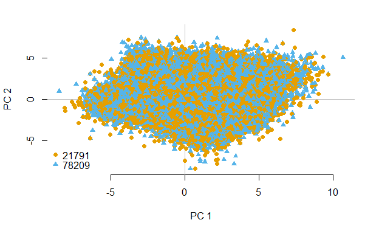

```r
pca2d(pca, group=gr, legend="bottomleft")
```

```r
ternaryScores <-ifelse(reviews$Score >= 4, "2", ifelse(reviews$Score == 3, "1", "0"))
gr <-  table(as.data.frame(ternaryScores))
head(gr)
```

```
    0     1     2
14384  7407 78209
```

```r
pca3d(pca, group=gr)
```

```
[1] 0.2136037 0.1674664 0.1692786
Creating new device
```